# NMDS and PCA examples

### Before we start

We will need the following packages:

```r
library(vegan)
library(dplyr)
```

Vegan is the go-to community ecology r package. dplyr is part of the tidyverse, and allows us to use piping %>% and allow us to use some commands to easily wrangle and tidy our data

## Ordination techniques

Ordination is a collective term for multivariate techniques which summarize a multidimensional dataset in such a way that when it is projected onto a low dimensional space, any intrinsic pattern the data may possess becomes apparent upon visual inspection (Pielou, 1984).

In ecology, ordination summarizes community data and produces a low-dimensional ordination space, where similar species are plotted closely together, similar samples are plotted close together, and dissimilar ones are far apart.

Using ordination techniques, we can determine the relative importance of different gradients and the graphical results from most techniques often lead to ready and intuitive interpretations of species-environment relationships.

We can use it for other multidimensional systems, such as weather.

## PCA

PCA has issues when beta diversity is moderate or high. So, it only really works with pretty similar communities! We will learn why this happens!

We have talked about this in class, but here is another good visual example. This is just showing us how PCA rotates the axes.

[figure not shown]

In most applications of PCA, variables are often measured in different units. For example, PCA of environmental data may include pH, soil moisture content, soil nitrogen, temperature and so on. For such data, the data must be standardized to zero mean and unit variance. For ordination of ecological communities, however, all species are measured in the same units, and the data do not need to be standardized.

Before we start, let’s get the data

We are going to:

1. load the varespec dataset
2. Use ?varespec to understand what this dataset entails
3. Look at the dataset

```r
data(varespec)
?varespec
```

```
## starting httpd help server ... done
```

```r
View(varespec)
```

We can DISPLAY bot the samples (or space) and the species!

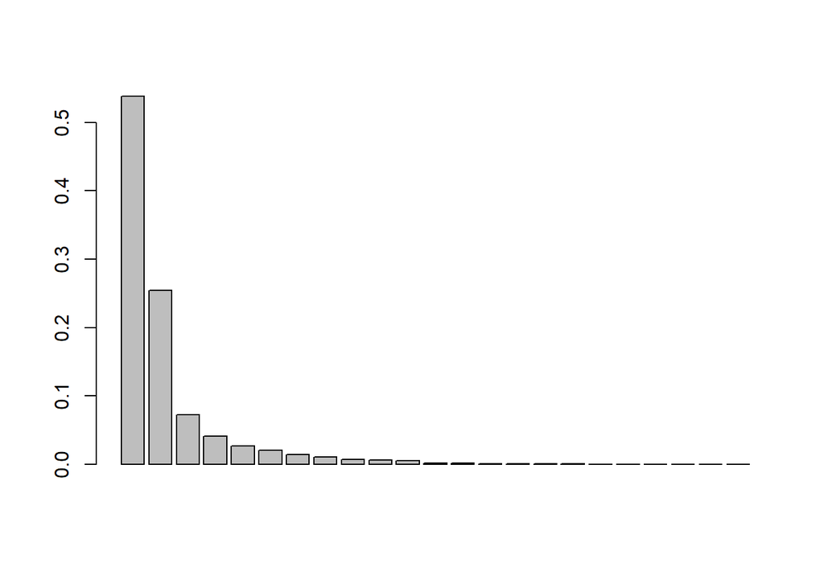

```r
PCA <- rda(varespec, scale = FALSE)
# Use scale = TRUE if your variables are on different scales (e.g. for abiotic variables).
# Here, all species are measured on the same scale
# So use scale = FALSE

# Now plot a bar plot of relative eigenvalues. This is the percentage variance explained by each axis
barplot(as.vector(PCA$CA$eig)/sum(PCA$CA$eig))
```

```r
# How much of the variance in our dataset is explained by the first principal component?
```

We can calculate the percent of variance explained by first two axes

```r
sum((as.vector(PCA$CA$eig)/sum(PCA$CA$eig))[1:2])
```

```
## [1] 0.7927453
```

```r
# Now, we`ll plot our results with the plot function
```

Now, we`ll plot our results with the plot function

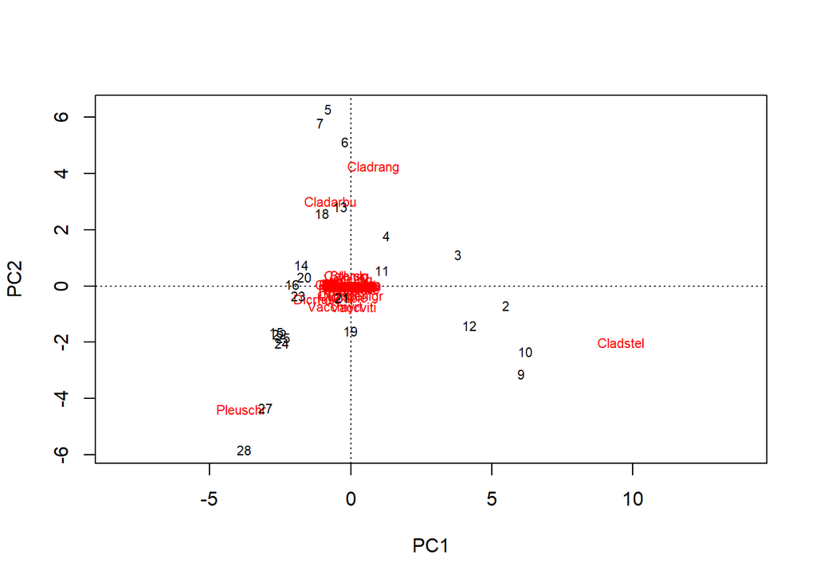

```r
plot(PCA)
```

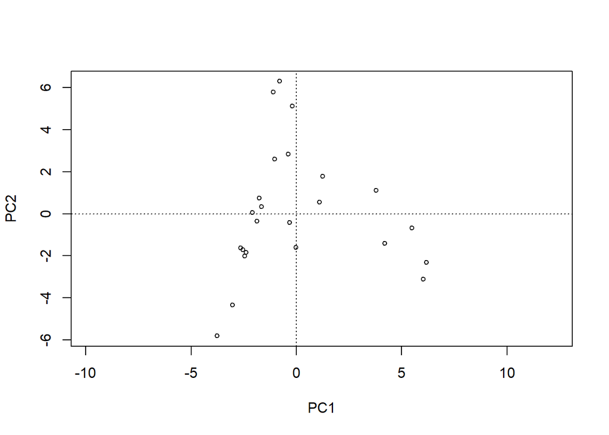

```r
plot(PCA, display = "sites", type = "points")
```

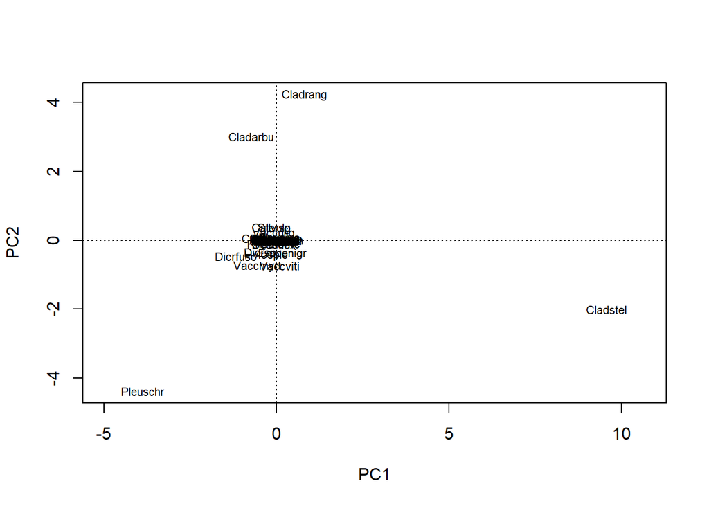

```r
plot(PCA, display = "species", type = "text")
```

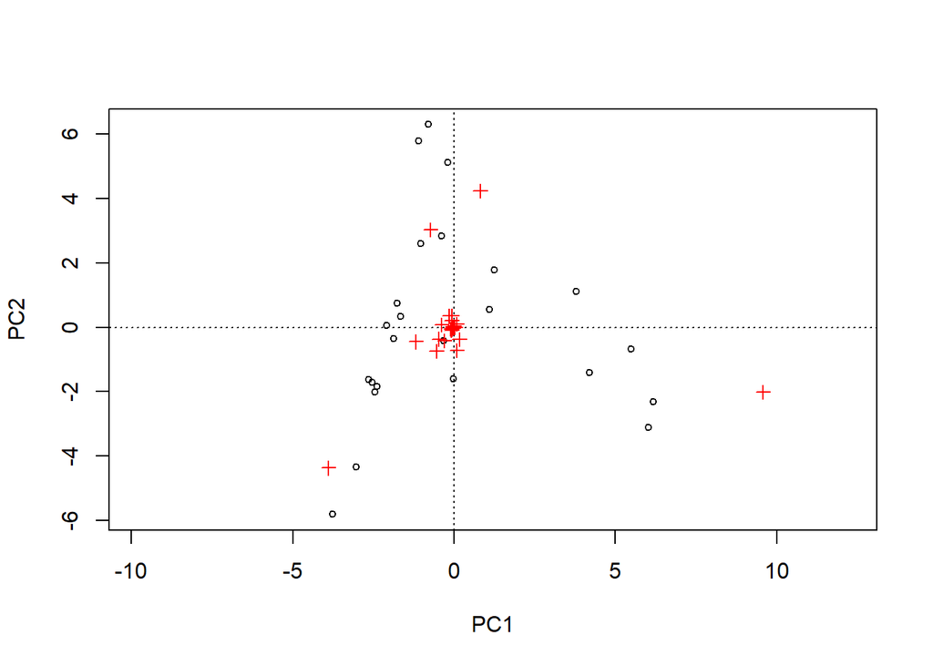

```r
plot(PCA, display = "sites", type = "points")
points(PCA, display = "species",col="red",pch=3)
```

Finally, we can actually plot the species scores (species space) using biplot:

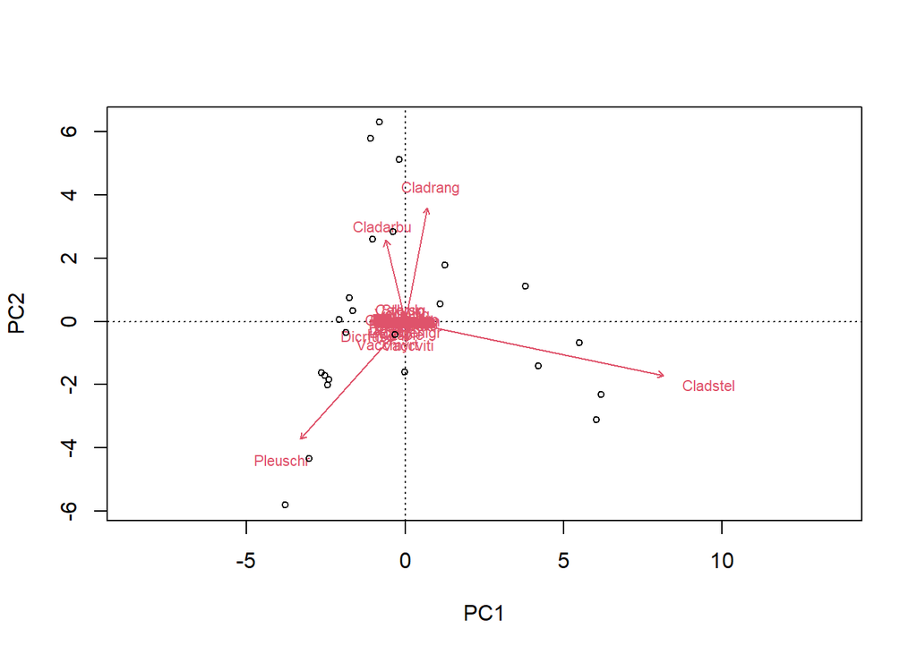

```r
biplot(PCA, choices = c(1,2), type = c("text", "points"), xlim = c(-5,10)) # biplot of axis 1 vs 2
```

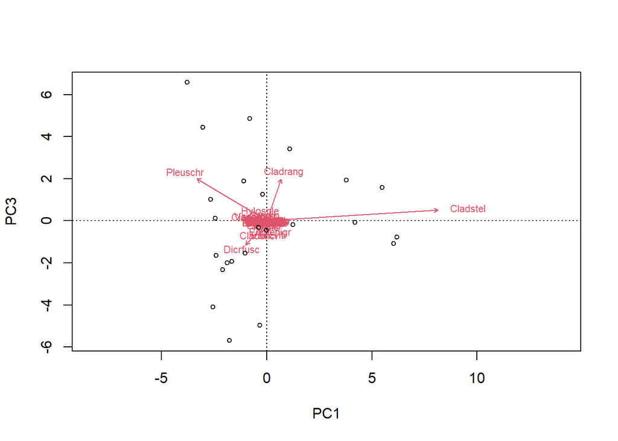

```r
biplot(PCA, choices = c(1,3), type = c("text","points")) # biplot of axis 1 vs 3
```

Now… There is a HUGE ISSUE with PCA. It is linear… This implies that the abundance of the species is continuously increasing in the direction of the arrow, and decreasing in the opposite direction. Thus PCA is a linear method. PCA is extremely useful when we expect species to be linearly (or even monotonically) related to each other. Unfortunately, we rarely encounter such a situation in nature. It is much more likely that species have a unimodal species response curve:

[figure not shown]

This also affects PCoA.

### Running an NMDS in R

Using the Varespec data, we can run the NMDS and plot it!

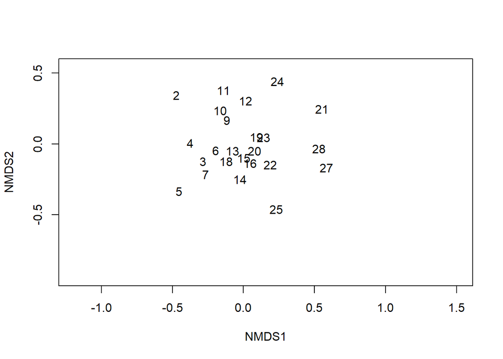

```r
varespec %>%metaMDS(trace = F)%>%ordiplot(type = "none")%>% text("sites")
```

Now we can see some patterns, some sites that are very similar are closely together! This is how we do a simple ordination plot.

The next steps, we will look at how to add some environmental covariates to it! The idea is to uncover the gradients, think of these gradients as the original dimensions. Something like this:

[figure not shown]

The main objectives of these methods (ordinaiton) in community ecology is to arrange samples or species (REMEMBER, there is a species space and a sample space, depending on in which space your axes are!) continuously among gradients

### NMDS

NMDS attempts to represent the pairwise dissimilarity between objects in a low-dimensional space. Any dissimilarity coefficient or distance measure may be used to build the distance matrix used as input. NMDS is a rank-based approach. This means that the original distance data is substituted with ranks.

**NMDS is not an eigenanalysis**. This has three important consequences:

- There is no unique ordination result
- The axes of the ordination are not ordered according to the variance they explain
- The number of dimensions of the low-dimensional space must be specified before running the analysis

There is no unique solution. The end solution depends on the random placement of the objects in the first step.

Axes are not ordered in NMDS. `metaMDS()` in `vegan` automatically rotates the final result of the NMDS using PCA to make axis 1 correspond to the greatest variance among the NMDS sample points. This doesn’t change the interpretation, cannot be modified, and is a good idea, but you should be aware of it.

**The stress** value reflects how well the ordination summarizes the observed distances among the samples.

A plot of stress (a measure of goodness-of-fit) vs. dimensionality can be used to assess the proper choice of dimensions. The stress values themselves can be used as an indicator. Stress values `>0.2` are generally poor and potentially uninterpretable, whereas values `<0.1` are good and `<0.05` are excellent, leaving little danger of misinterpretation. Stress values between `0.1` and `0.2` are useable but some of the distances will be misleading. Finding the inflexion point can instruct the selection of a minimum number of dimensions.

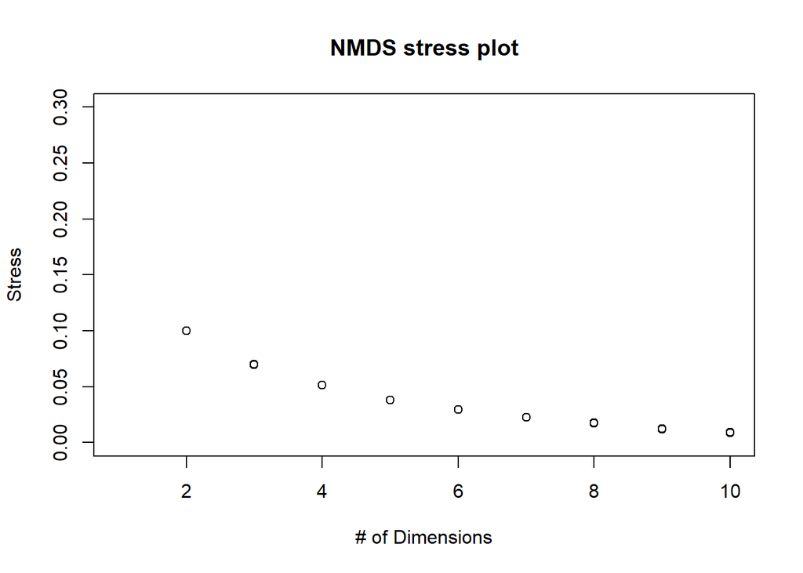

```r
# First step is to calculate a distance matrix. See PCOA for more information about the distance measures
# Here we use bray-curtis distance, which is recommended for abundance data
dist <- vegdist(varespec,  method = "bray")

# In this part, we define a function NMDS.scree() that automatically
# performs a NMDS for 1-10 dimensions and plots the nr of dimensions vs the


NMDS.scree <- function(x) { #where x is the name of the data frame variable
  plot(rep(1, 10), replicate(10, metaMDS(x, autotransform = F, k = 1)$stress), xlim = c(1, 10),ylim = c(0, 0.30), xlab = "# of Dimensions", ylab = "Stress", main = "NMDS stress plot")
  for (i in 1:10) {
    points(rep(i + 1,10),replicate(10, metaMDS(x, autotransform = F, k = i + 1)$stress))
  }
}

# Use the function that we just defined to choose the optimal nr of dimensions
NMDS.scree(dist)
```

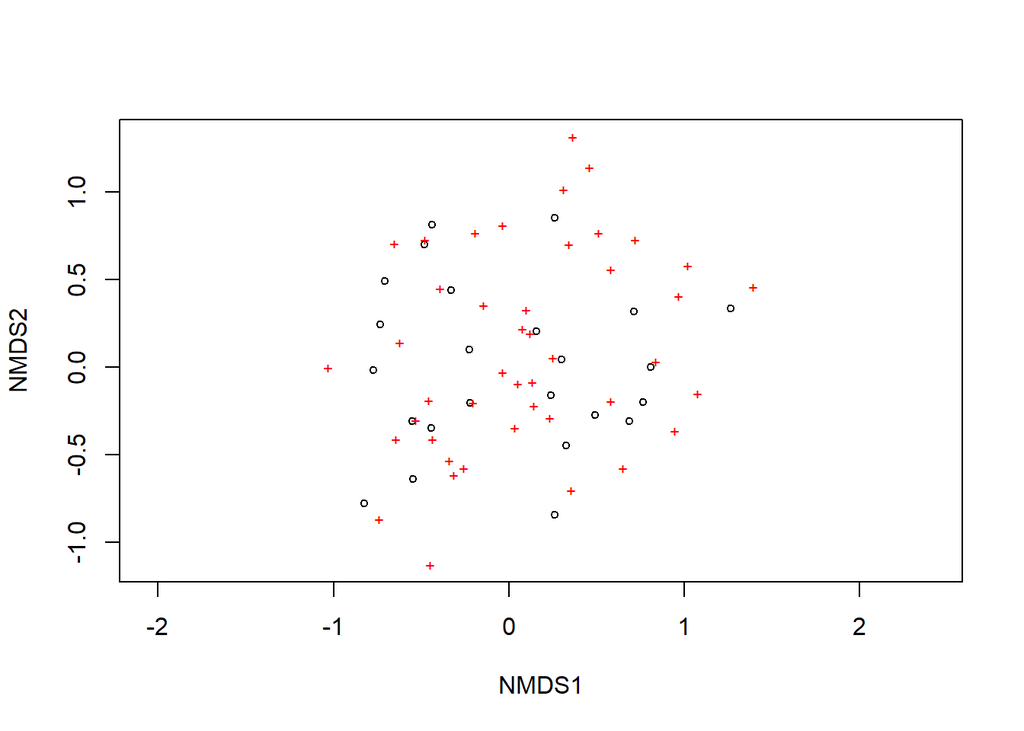

```r
NMDS3 <- metaMDS(varespec, k = 2, trymax = 100, trace = F, autotransform = FALSE, distance="bray")
plot(NMDS3)
```

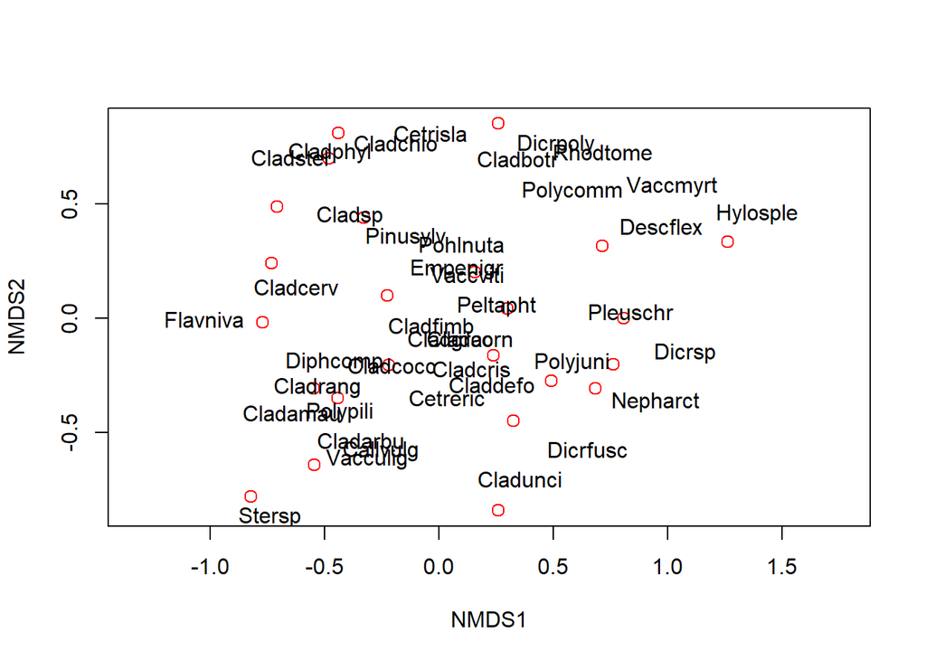

```r
plot(NMDS3, display = "sites", type = "n")
points(NMDS3, display = "sites", col = "red", cex = 1.25)
text(NMDS3, display ="species")
```

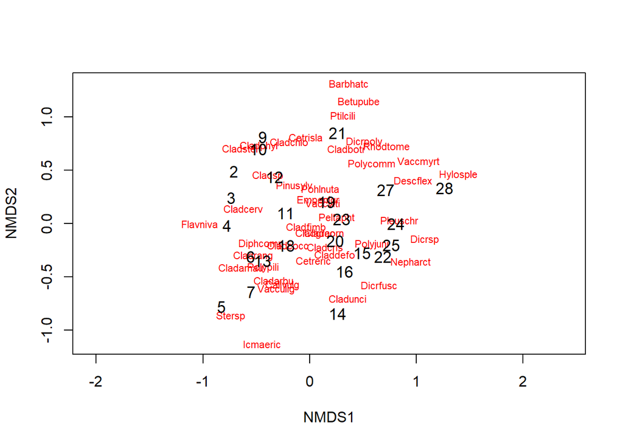

```r
# Alternatively, you can use the functions ordiplot and orditorp
ordiplot(NMDS3, type = "n")
orditorp(NMDS3, display = "species", col = "red", air = 0.01)
orditorp(NMDS3, display = "sites", cex = 1.1, air = 0.01)
```

Now… We now have a nice ordination plot and we know which plots have a similar species composition. We also know that the first ordination axis corresponds to the largest gradient in our dataset (the gradient that explains the most variance in our data), the second axis to the second biggest gradient and so on. **The next question is: Which environmental variable is driving the observed differences in species composition?** We can do that by correlating environmental variables with our ordination axes. Therefore, we will use a second dataset with environmental variables (sample by environmental variables). We continue using the results of the NMDS.

```r
# Load the second dataset
data(varechem)

# The function envfit will add the environmental variables as vectors to the ordination plot
ef <- envfit(NMDS3, varechem, permu = 999)
ef
```

```
##
## ***VECTORS
##
##             NMDS1    NMDS2     r2 Pr(>r)
## N         0.01869 -0.99983 0.1885  0.114
## P         0.66078  0.75058 0.2898  0.028 *
## K         0.85358  0.52096 0.1830  0.128
## Ca        0.83357  0.55241 0.3534  0.010 **
## Mg        0.84816  0.52975 0.2901  0.032 *
## S         0.41306  0.91070 0.0884  0.385
## Al       -0.98935  0.14558 0.4888  0.001 ***
## Fe       -0.99350  0.11386 0.4081  0.004 **
## Mn        0.99234  0.12357 0.4293  0.004 **
## Zn        0.92741  0.37404 0.1650  0.146
## Mo       -0.85990 -0.51046 0.0476  0.616
## Baresoil  0.91935 -0.39344 0.1877  0.115
## Humdepth  0.98856  0.15085 0.4415  0.004 **
## pH       -0.86063  0.50924 0.2252  0.064 .
## ---
## Signif. codes:  0 '***' 0.001 '**' 0.01 '*' 0.05 '.' 0.1 ' ' 1
## Permutation: free
## Number of permutations: 999
```

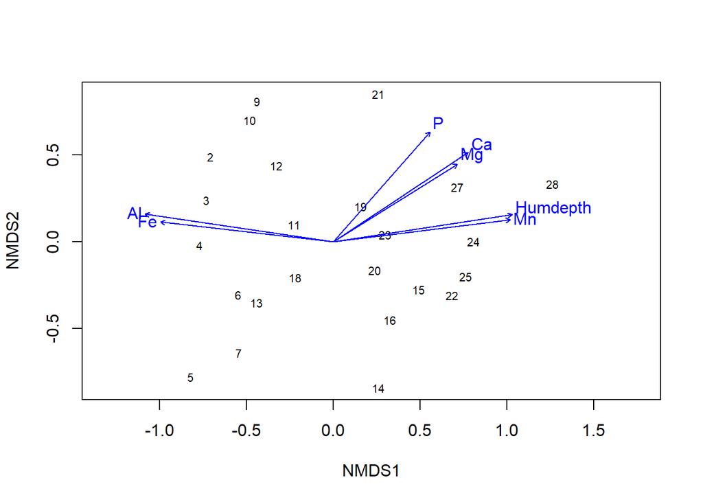

```r
# The two last columns are of interest: the squared correlation coefficient and the associated p-value
# Plot the vectors of the significant correlations and interpret the plot
plot(NMDS3, type = "t", display = "sites")
plot(ef, p.max = 0.05)
```

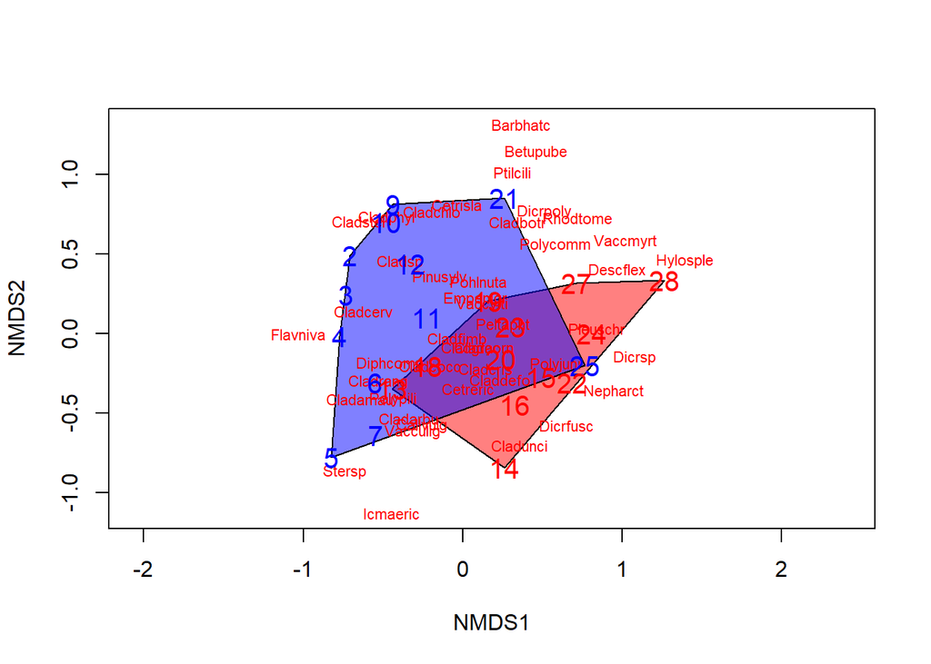

[figure not shown]

```r
# Define a group variable (first 12 samples belong to group 1, last 12 samples to group 2)
group = c(rep("Group1", 12), rep("Group2", 12))

# Create a vector of color values with same length as the vector of group values
colors = c(rep("red", 12), rep("blue", 12))

# Plot convex hulls with colors based on the group identity
ordiplot(NMDS3, type = "n")
for(i in unique(group)) {
  ordihull(NMDS3$point[grep(i, group),], draw="polygon",
   groups = group[group == i],col = colors[grep(i,group)],label=F) }

orditorp(NMDS3, display = "species", col = "red", air = 0.01)
orditorp(NMDS3, display = "sites", col = c(rep("red",12),
  rep("blue", 12)), air = 0.01, cex = 1.25)
```